# Spatiotemporal Analysis of Tuberculosis using Hausdorff–Gaussian Processes

Available at lcgodoy.me/slides/2024-cobal/

Lucas da Cunha Godoy

ldcgodoy@ucsc.com

EEB Department, UCSC

VII COBAL & XVII EBEB – UFMG

2024-12-05

# Introduction

## Too many slides…

[figure not shown]

## Tuberculosis in context

- Mortality: Tuberculosis (TB) remains a major global health threat, second in infectious disease mortality only to COVID-19.
- Rio Grande do Sul (RS) reported significantly higher incidence than the national average in 2021, with the eastern region even more affected.
- Dependence: Studies demonstrate strong spatial dependence of TB infections in Brazil, but temporal and spatiotemporal structures have been largely overlooked.
- Risk Factors: TB risk factors include densely populated areas, poverty, substance abuse, and incarceration (Cortez et al. 2021).

## Spatiotemporal (SPT) models for areal data

- Spatial models: CAR (Besag 1974), ICAR, BYM (Besag et al. 1991), DAGAR (Datta et al. 2019), RENeGe (Cruz-Reyes et al. 2023).
- Nonseparable SPT models are more complex as they consider that the spatial and temporal correlations might be intertwined (Cressie and Wikle 2015, pg. 309–321).
- Separable models one way to look at these models is as multivariate spatial processes (MacNab 2022).
- Advantages of separable models: Computational efficiency & positive-definiteness of the covariance function.

## Proposed methodology & Objectives

- Hausdorff–Gaussian Process (HGP): we propose using the newly developed HGP for the spatial portion of the model (Godoy et al. 2024).
- Reliable incidence estimates:
  - Smaller municipalities benefit from borrowed strength from neighbors, improving estimate reliability.
  - Results enable the calculation of standardized incidence ratios to pinpoint high-risk areas.
- Forecasting: Predicted TB incidence rates one year ahead offer crucial insights for proactive public health planning.

# Hausdorff–Gaussian Process (HGP)

## Preliminaries

- Areal spatial units are (closed and bounded) sets.
- We need to generalize distance between points to distance between sets.
- Ideally, this distance should:
  1. Take into account the shape, size, and orientation of spatial sample units.
  2. Be “spatially interpretable”.

## Distances between sets

- Distance between a point and a set: $d(x, A) = \inf_{a \in A} d(x, a)$, where $d(x, y)$ is the distance between any two elements $x, y \in D$
- Directed Hausdorff & Hausdorff distance:
  $${\vec h}(A, B) =
  \sup_{a \in A} d(a, B) \quad \text{and} \quad h(A, B) = \max \left \{
  \vec{h}(A, B), \vec{h}(B, A) \right \}$$

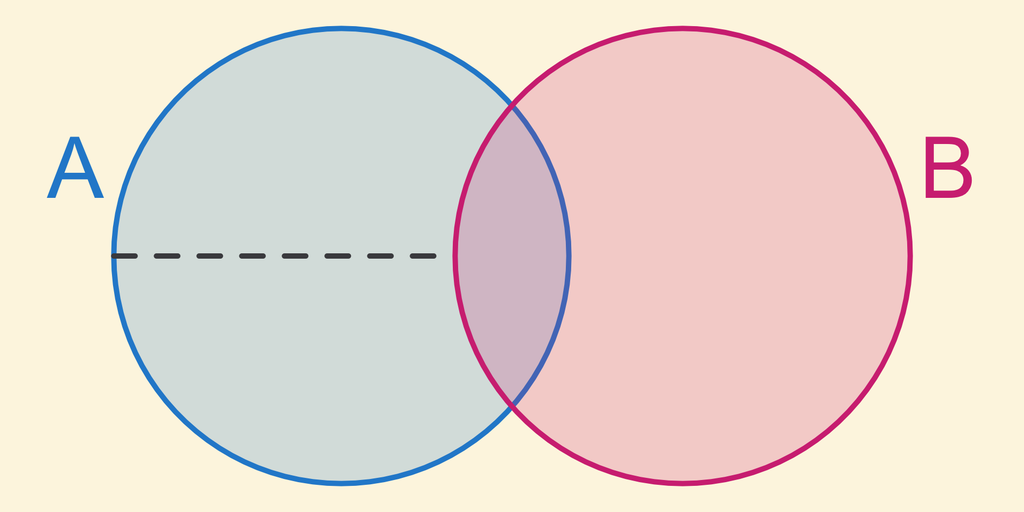

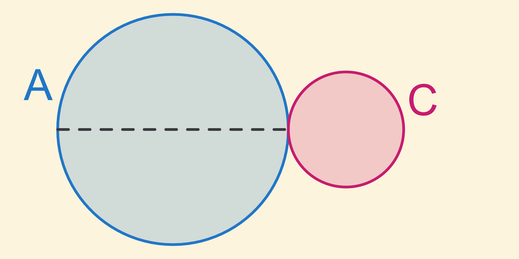

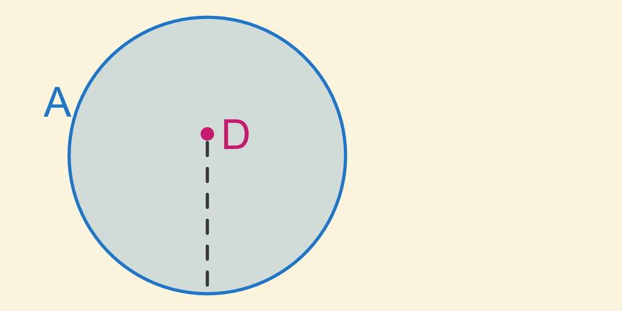

## The HGP

- General spatial model: $\{ Z(\mathbf{s}) \; : \; \mathbf{s} \in \mathcal{B}(D) \}$.
- Index set: $\mathcal{B}(D)$ represents the closed and bounded subsets of $D \subset \mathbb{R}^2$.
- Assumption: The HGP assumes $Z(\mathbf{s})$ to be an isotropic Gaussian Process such that its spatial correlation function depends on the Hausdorff distance.
- Powered Exponential Correlation (PEC) function: $r(h) = \exp\left \{ - \frac{h^{\nu}}{\phi^{\nu}}\right \},$ where $h$ denotes the Hausdorff distance between $\mathbf{s}_1, \mathbf{s}_2 \in \mathcal{B}(D)$.

# Tuberculosis spatiotemporal modeling

## Data & Model

- Sample units: 54 municipalities, across 11 years (2011 to 2021). We use 2022 to assess the quality of predictions.
- Number of TB cases: $Y_t(\mathbf{s}_i)$ at location $\mathbf{s}_i$ and time $t$.
- Population: $P_t(\mathbf{s}_i)$.
- Five covariates and two way interactions with presence of prison (except IDESE).

$$\begin{aligned}
& (Y_t(\mathbf{s}_i) \mid \mathbf{X}_{t}(\mathbf{s}_i), Z(\mathbf{s}_i, t))
\overset{{\rm ind}}{\sim}
\text{Poisson}(P_t(\mathbf{s}_i) \mu_{it}) \\
& \log(\mu_{it}) = \alpha + \mathbf{X}^\top_{t}(\mathbf{s}_i) \beta + Z(\mathbf{s}_i, t)
\end{aligned}$$

## Priors

- We assume $Z(\mathbf{s}, t)$ is a separable zero-mean Gaussian model such that its SPT covariance matrix is the kronecker product between a spatial covariance (HGP, BYM, & DAGAR) and a temporal correlation ($\mathrm{AR}(1)$).
- HGP spatial dependence: $\rho \sim \mathrm{Exp}(a_\rho)$, where $a_{\rho} = - \log(p_{\rho}) / \rho_0$. $a_\rho$ is chosen such that $\mathbb{P}(\rho > \rho_0) = p_\rho$.
- Smoothness & marginal SD: $\nu \sim \mathrm{Beta}(2.5, 1.5)$ (mode at $0.75$) & $\sigma \sim t_{+}(3)$.
- Temporal dependence: PC prior (Sørbye and Rue 2017) where $\mathbb{P}(\lvert \psi \rvert > 0.8) = 0.1$.
- Intercept & regression coefficients: $\alpha$ (i.e., $\pi(\alpha) \propto 1$) & $\boldsymbol{\beta} \sim \mathcal{N}(\mathbf{0}, 10 \mathbf{I})$

## Computational considerations

- Super effortful: $vec(\mathbf{Z}) \sim \mathcal{N}(\mathbf{0}, \sigma^2 \mathrm{R}_s \otimes \mathrm{R}_t)$ requires $\mathcal{O}(N^3 T^3)$ *flops* (and storage).
- Effortful: With linear algebra, we can reduce the computational complexity (and storage) to $\approx \mathcal{O}(N^3 + T^3)$
- Neutral: More linear algebra can be used to evaluate a quadratic form with less operations.
- Clever: The Cholesky decomposition of $R^{-1}_t$ is tridiagonal.
- Super clever: The complexity to obtain $chol(R^{-1}_s)$ is dramatically decreased using nearest-neighbor approximations (Finley et al. 2019).

## Bayesian Inference & Model Assessment

- Posterior: $\pi(\boldsymbol{\theta} \mid \mathbf{y}, \mathbf{z}) \propto p(\mathbf{y} \mid \mathbf{z}, \boldsymbol{\theta}) p(\mathbf{z} \mid \boldsymbol{\theta}) \pi(\boldsymbol{\theta})$
- MCMC sampler: No-U-Turn (Homan and Gelman 2014).
- Convergence assessment: traceplots and split-${\hat{R}}$ (Vehtari et al. 2021).
- Goodness-of-fit criteria: LOOIC (lower values indicate better fit)
- Posterior predictive distributions: $p(\mathbf{y}^{\ast} \mid \mathbf{y})$
- Predictions assessment: Interval Score (IS) and RMSP (lower values indicate better fit)

## Spatiotemporal Trend

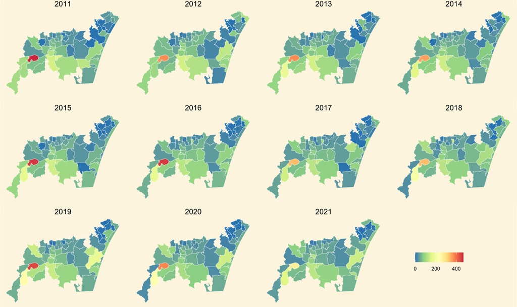

## Explanatory Variables

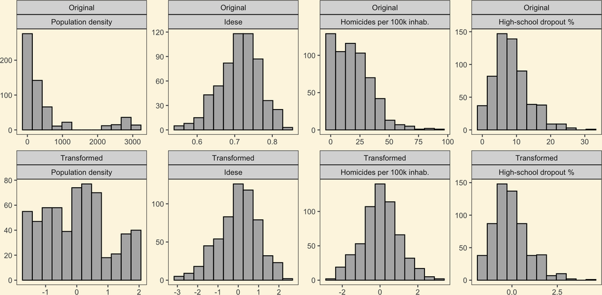

## Results: GOF and Predictive Performance

|  | LOOIC | RMSP | IS |
| --- | --- | --- | --- |
| HGP | 3516.1 | 21.1 | 87.8 |
| BYM | 3606.1 | 123.3 | 176.6 |
| DAGAR | 3520.9 | 22.4 | 88.8 |

## Results: Relative Risks

| Parameter | Description | Estimate |
| --- | --- | --- |
| $\exp(\beta_1)$ | Prison | 2.34 (1.70, 3.19) |
| $\exp(\beta_2)$ | Pop / km<sup>2</sup> | 1.33 (1.15, 1.56) |
| $\exp(\beta_2 + \beta_{21})$ |  | 1.75 (1.18, 2.52) |
| $\exp(\beta_3)$ | HS dropout % | 1.03 (0.99, 1.07) |
| $\exp(\beta_3 + \beta_{31})$ |  | 2.25 (1.63, 3.09) |
| $\exp(\beta_4)$ | Homicide rate | 0.97 (0.93, 1.00) |
| $\exp(\beta_4 + \beta_{41})$ |  | 2.51 (1.83, 3.46) |
| $\exp(\beta_5)$ | IDESE | 0.99 (0.92, 1.07) |

## Spatiotemporal Dependence

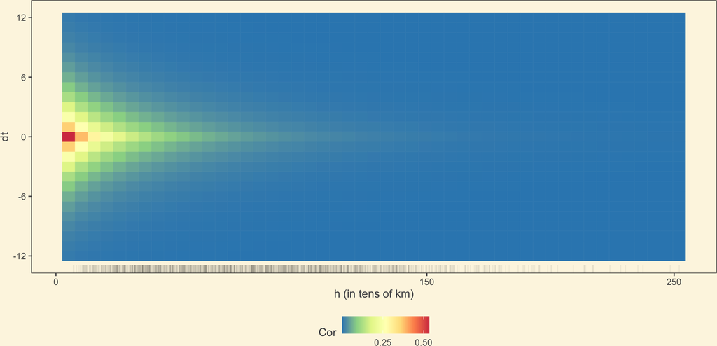

## Small Municipalities

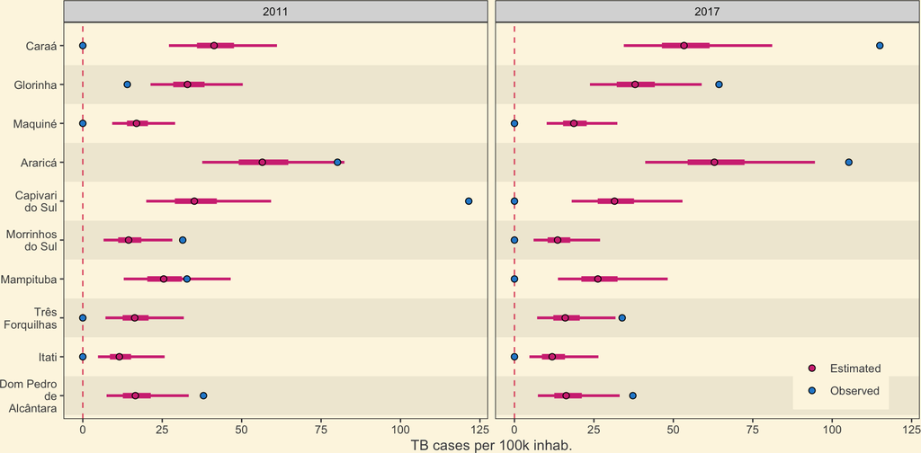

## Forecast

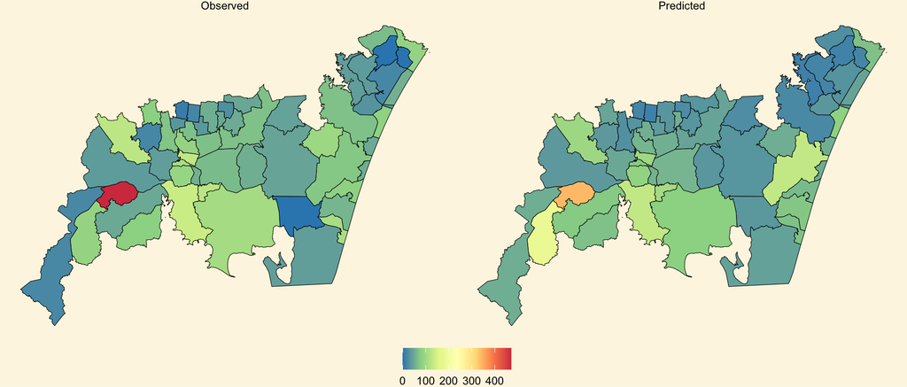

# Closing remarks

## Closing remarks

- **Tailored an HGP extension for spatiotemporal disease mapping.**
- Competitive with specialized models
- It helps to gain insights into spatiotemporal disease mapping through spatiotemporal correlation functions.
- More reliable estimates of risk factors
- Out-of-sample predictions to inform public policies

### References

Besag, J. (1974), “Spatial interaction and the statistical analysis of lattice systems,” *Journal of the Royal Statistical Society. Series B (Methodological)*, JSTOR, 192–236.

Besag, J., York, J., and Mollié, A. (1991), “Bayesian image restoration, with two applications in spatial statistics,” *Annals of the Institute of Statistical Mathematics*, 43, 1–20.

Cortez, A. O., Melo, A. C. de, Neves, L. de O., Resende, K. A., and Camargos, P. (2021), “Tuberculosis in Brazil: One country, multiple realities,” *Jornal Brasileiro de Pneumologia*, Sociedade Brasileira de Pneumologia e Tisiologia, 47, e20200119. https://doi.org/10.36416/1806-3756/e20200119.

Cressie, N., and Wikle, C. K. (2015), *[Statistics for spatio-temporal data](https://books.google.com/books?id=4L_dCgAAQBAJ)*, Wiley.

Cruz-Reyes, D. L., Assunção, R. M., and Loschi, R. H. (2023), “Inducing high spatial correlation with randomly edge-weighted neighborhood graphs,” *Bayesian Analysis*, International Society for Bayesian Analysis, 1, 1–35.

Datta, A., Banerjee, S., Hodges, J. S., and Gao, L. (2019), “Spatial disease mapping using directed acyclic graph auto-regressive (DAGAR) models,” *Bayesian analysis*, NIH Public Access, 14, 1221.

Diggle, P. J., Tawn, J. A., and Moyeed, R. A. (1998), “Model-based geostatistics,” *Journal of the Royal Statistical Society Series C: Applied Statistics*, Oxford University Press, 47, 299–350.

Finley, A. O., Datta, A., Cook, B. D., Morton, D. C., Andersen, H. E., and Banerjee, S. (2019), “Efficient algorithms for bayesian nearest neighbor gaussian processes,” *Journal of Computational and Graphical Statistics*, ASA Website, 28, 401–414. https://doi.org/10.1080/10618600.2018.1537924.

Godoy, L. da C., Prates, M. O., and Yan, J. (2024), “Statistical inferences and predictions for areal data and spatial data fusion with hausdorff–gaussian processes,” *Journal of the American Statistical Association (under review)*. https://doi.org/10.48550/arXiv.2208.07900.

Homan, M. D., and Gelman, A. (2014), “The No-U-turn sampler: Adaptively setting path lengths in hamiltonian Monte Carlo,” *Journal of Machine Learning Research*, JMLR.org, 15, 1593–1623.

MacNab, Y. C. (2022), “Bayesian disease mapping: Past, present, and future,” *Spatial Statistics*, Elsevier, 50, 100593.

Min, D., Zhilin, L., and Xiaoyong, C. (2007), “Extended Hausdorff distance for spatial objects in GIS,” *International Journal of Geographical Information Science*, Taylor & Francis, 21, 459–475.

Sørbye, S. H., and Rue, H. (2017), “Penalised complexity priors for stationary autoregressive processes,” *Journal of Time Series Analysis*, Wiley Online Library, 38, 923–935.

Vehtari, A., Gelman, A., Simpson, D., Carpenter, B., and Bürkner, P.-C. (2021), “Rank-normalization, folding, and localization: An improved $\hat{R}$ for assessing convergence of MCMC (with discussion),” *Bayesian Analysis*, International Society for Bayesian Analysis, 16, 667–718.

# Thank you!

[figure not shown]

# Appendix

## Sensitivity analysis

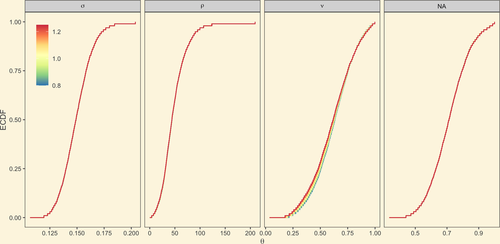